# SDS315HW5

Max Allen

2024-02-26

# Problem 1

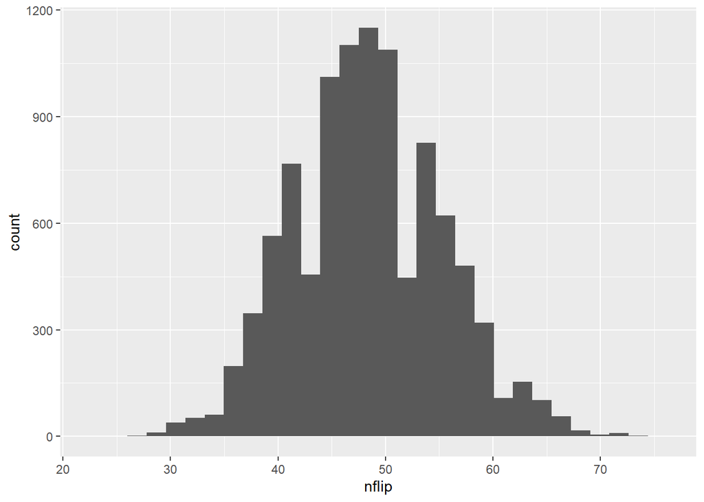

I want to find whether the Iron Bank is getting flagged for illegal activity significantly higher than the standard flag rate which is .024. The null hypothesis would be that there is no significant difference in the Iron Bank’s tendencies of getting flagged. The bank claimed they were flagged 70 times out of their last 2021 transactions, 0.03. The plot above displays a distribution which should be expected if the null hypothesis is true. The amount proportion of instances of 70 or greater is 0.0018.This to be possible by sheer luck, but I believe it warrants further investigation into the Iron Bank as the value is unusually low.

# Problem 2

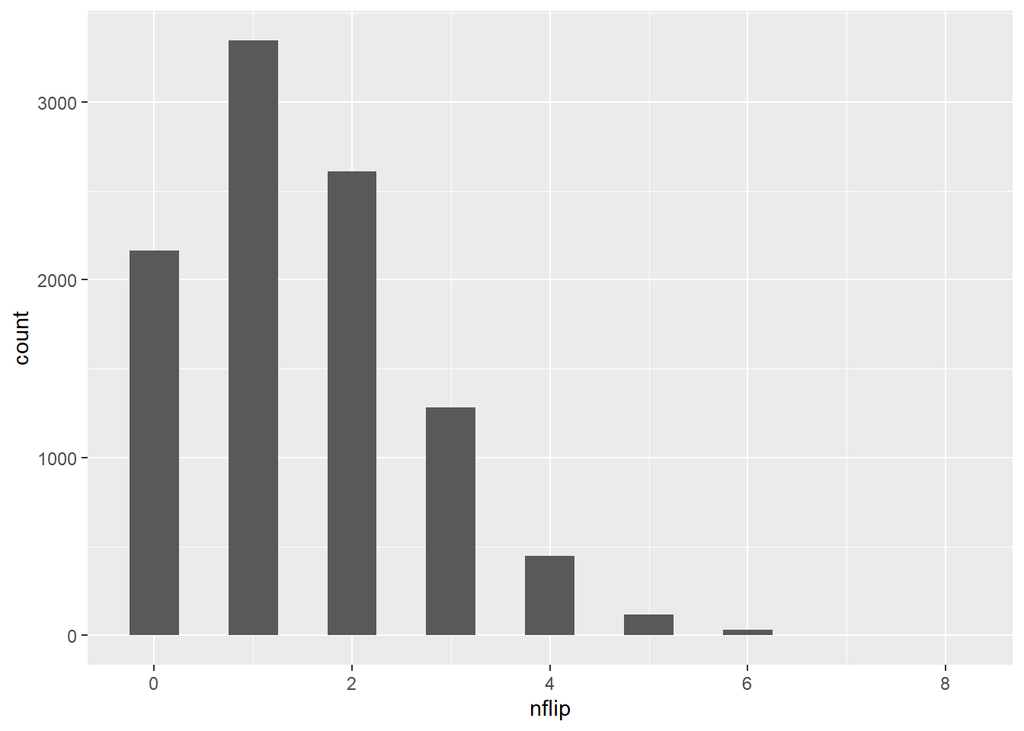

Here, I’m investigating whether or not Gourmet Bites gets more health violations than should be expected. The expected rate of violations for sound businesses-the null hypothesis-is 3%. Gourmet Bites received violations in 16% of their 50 inspections. The graph above shows the expected distribution of violations should Gourmet Bites be a regular upstanding business. The p-value ends up being 10^{-4}. A value that low is extremely improbable, and I would believe that the null hypothesis should be rejected and Gourmet Bites’ should be investigated.

# Problem 3

For this problem I will be investigating whether sentences are watermarked: created and imprinted by an AI generation tool, or if they are natural English sentences. I will have to do this in two parts, first create a basis by comparing natural sentences to the expected letter counts and then using this basis to test the ten given sentences.

### Part A

Now I have a null distribution that has 56745 entries of normal sentences and their chi-squared values that I can use for part B.

### Part B

```
##  [1] 0.512838136 0.926284254 0.076376773 0.489065116 0.484060270 0.008776104
##  [7] 0.327923165 0.988016565 0.084060270 0.059036038
```

Above are printed the 10 p-values for each sentence in order. This value represents the proportion of chi-squared values in the distribution from part A that as large or larger than the given sentence’s chi-squared score. The sixth sentence must be the one that was affected by watermarking. Every other p-value is .05 or greater, yet it sits at 0.0087761. This means only 0.88% of the brown sentences have a more irregular distribution.